# Beer and Brew Project

Anthony Burton-Cordova

2022-10-22

# Beer and Brewery Data

## Presenting Findings of Beer and Breweries

### R Data Manipuilationn and Import. Pre load packages

```r
library(knitr)
library(e1071)
library(caret)
library(class)
library(tidyverse)
```

```r
library(stringr)
library(dplyr)
library(ggplot2)
library(tidyr)
library(knitr)
library(rmarkdown)
```

Read in file

```r
#Reading our Beer and Brewery Files
totalBeer = read.csv('https://raw.githubusercontent.com/BivinSadler/MSDS_6306_Doing-Data-Science/Master/Unit%208%20and%209%20Case%20Study%201/Beers.csv', header = TRUE)
totalBrew = read.csv('https://raw.githubusercontent.com/BivinSadler/MSDS_6306_Doing-Data-Science/Master/Unit%208%20and%209%20Case%20Study%201/Breweries.csv', header = TRUE)
```

Define a graph with breweries per state

```r
#1) How many breweries are present in each state?
totalBrew %>% group_by(State) %>% count(State)
```

```
## # A tibble: 51 × 2
## # Groups:   State [51]
##    State     n
##    <chr> <int>
##  1 " AK"     7
##  2 " AL"     3
##  3 " AR"     2
##  4 " AZ"    11
##  5 " CA"    39
##  6 " CO"    47
##  7 " CT"     8
##  8 " DC"     1
##  9 " DE"     2
## 10 " FL"    15
## # … with 41 more rows
```

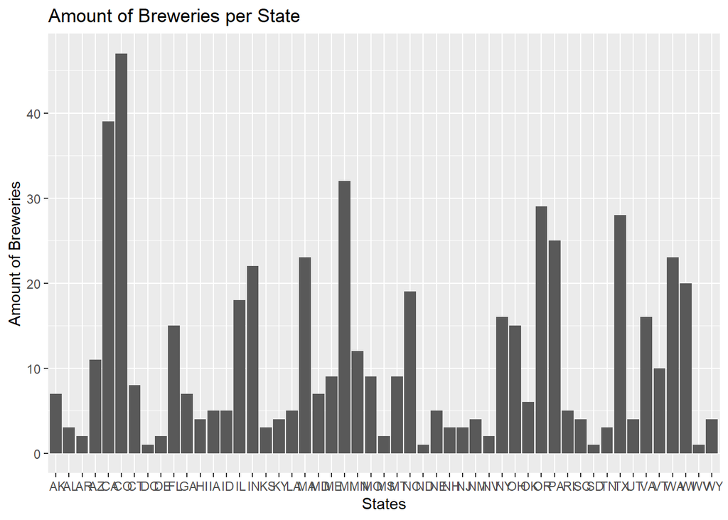

```r
ggplot(totalBrew, aes(x = State), fill = State) + geom_bar() + labs(title ="Amount of Breweries per State", x = "States", y = "Amount of Breweries")
```

We calculated the number of Breweries present in each state. The first 5 states are as follows; Alaska has 7, Alabama has 3, Arkansas has 2, Arizona has 11, California has 39. You can find the additional read out in the graph.

Merge both data

```r
#2) Merging Beer and Brewery data
#Checking dimensions of both dataframes
dim(totalBeer)
```

```
## [1] 2410    7
```

```r
dim(totalBrew)
```

```
## [1] 558   4
```

```r
#Merging Beer is totalBeer and Brewery is totalBrew.
mergedB = merge(totalBeer, totalBrew, by.x = "Brewery_id", by.y = "Brew_ID")
dim(mergedB)
```

```
## [1] 2410   10
```

```r
#Looking at the first 6 observations.
head(mergedB, n=6)
```

```
##   Brewery_id        Name.x Beer_ID   ABV IBU
## 1          1  Get Together    2692 0.045  50
## 2          1 Maggie's Leap    2691 0.049  26
## 3          1    Wall's End    2690 0.048  19
## 4          1       Pumpion    2689 0.060  38
## 5          1    Stronghold    2688 0.060  25
## 6          1   Parapet ESB    2687 0.056  47
##                                 Style Ounces             Name.y        City
## 1                        American IPA     16 NorthGate Brewing  Minneapolis
## 2                  Milk / Sweet Stout     16 NorthGate Brewing  Minneapolis
## 3                   English Brown Ale     16 NorthGate Brewing  Minneapolis
## 4                         Pumpkin Ale     16 NorthGate Brewing  Minneapolis
## 5                     American Porter     16 NorthGate Brewing  Minneapolis
## 6 Extra Special / Strong Bitter (ESB)     16 NorthGate Brewing  Minneapolis
##   State
## 1    MN
## 2    MN
## 3    MN
## 4    MN
## 5    MN
## 6    MN
```

```r
#Looking at the last 6 observations.
tail(mergedB, n = 6)
```

```
##      Brewery_id                    Name.x Beer_ID   ABV IBU
## 2405        556             Pilsner Ukiah      98 0.055  NA
## 2406        557  Heinnieweisse Weissebier      52 0.049  NA
## 2407        557           Snapperhead IPA      51 0.068  NA
## 2408        557         Moo Thunder Stout      50 0.049  NA
## 2409        557         Porkslap Pale Ale      49 0.043  NA
## 2410        558 Urban Wilderness Pale Ale      30 0.049  NA
##                        Style Ounces                        Name.y          City
## 2405         German Pilsener     12         Ukiah Brewing Company         Ukiah
## 2406              Hefeweizen     12       Butternuts Beer and Ale Garrattsville
## 2407            American IPA     12       Butternuts Beer and Ale Garrattsville
## 2408      Milk / Sweet Stout     12       Butternuts Beer and Ale Garrattsville
## 2409 American Pale Ale (APA)     12       Butternuts Beer and Ale Garrattsville
## 2410        English Pale Ale     12 Sleeping Lady Brewing Company     Anchorage
##      State
## 2405    CA
## 2406    NY
## 2407    NY
## 2408    NY
## 2409    NY
## 2410    AK
```

The first 6 observable beers from the output are as follows: Get Together, Maggie’s Leap, Wall’s End, Pumpion, Stronghold, and Parapet ESB.

The Last 6 observable beers from the output are as follows: Pilsner Ukiah, Heinnieweisse Weissebier, Snapperhead IPA, Moo Thunder Stout, Porkslap Pale Ale, and Urban Wilderness Pale Ale

Cleaning data

```r
#3) Addressing the missing values in each column.
##Cleaning up data by removing NAs.
mergedB = na.omit(mergedB)
dim(mergedB)
```

```
## [1] 1405   10
```

Plot a chart after finding the meadians of each variable

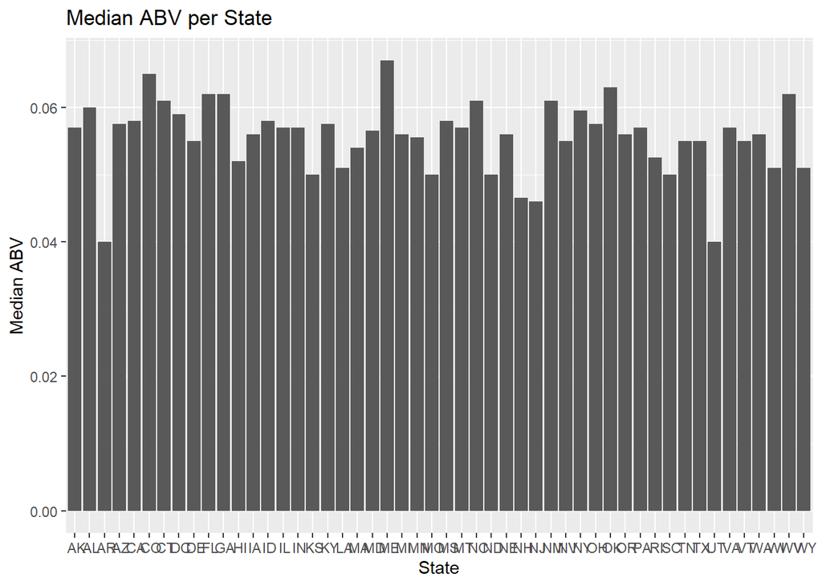

```r
#4) Computing the median Alcohol Content (ABV) and International Bitterness Unit (IBU) for each state. Plot a bar chart to compare.
#This gives us the median for alcohol content.
medianABV = median(mergedB$ABV)

#Getting the median of bitterness is given by this code.
medianIBU = median(mergedB$IBU)

medFrame = mergedB %>% group_by(State) %>% summarise(medianABV = median(ABV), medianIBU = median(IBU))

#Plotting via bar charts, shows the Median ABV per State.
ggplot(medFrame, aes(x = State, y = medianABV)) + geom_bar(stat = 'identity') + labs(title = "Median ABV per State", y = "Median ABV")
```

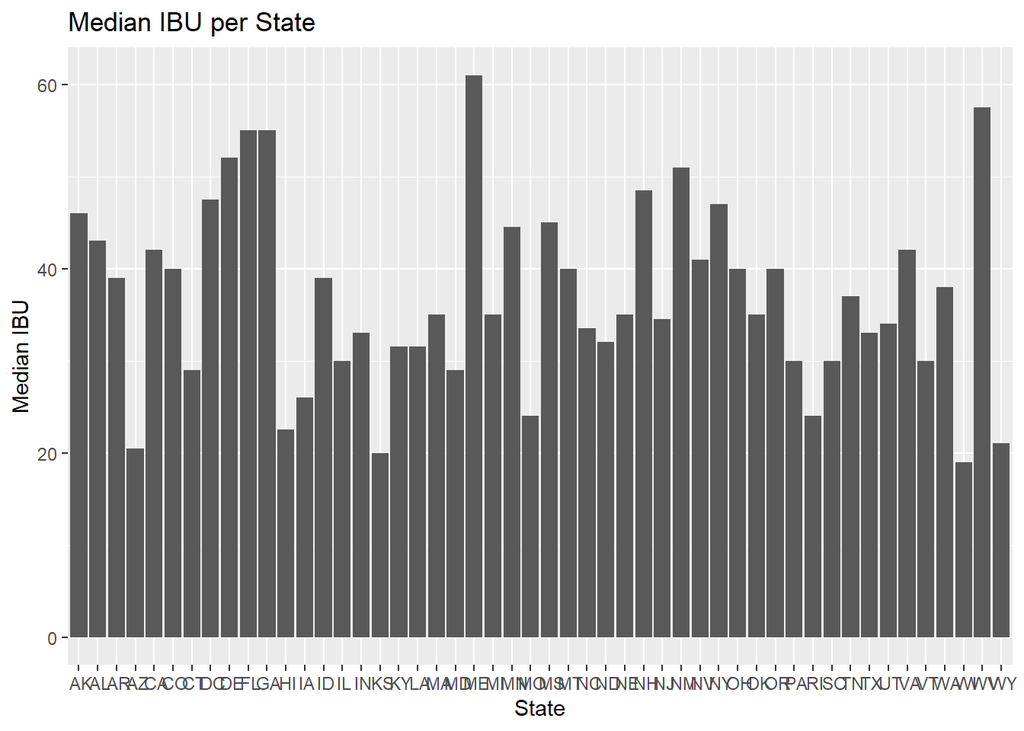

```r
#This will give us the Median IBU per State.
ggplot(medFrame, aes(x = State, y = medianIBU), color = "yellow") + geom_bar(stat = 'identity') + labs(title = "Median IBU per State", y = "Median IBU")
```

Arrange rows to find the max of each variable

```r
#5) Which state has the maximum alcoholic (ABV) beer?
##Arranging the rows in descending order with reference to ABV.
arrange(medFrame, desc(medianIBU))
```

```
## # A tibble: 50 × 3
##    State medianABV medianIBU
##    <chr>     <dbl>     <dbl>
##  1 " ME"    0.067       61
##  2 " WV"    0.062       57.5
##  3 " FL"    0.062       55
##  4 " GA"    0.062       55
##  5 " DE"    0.055       52
##  6 " NM"    0.061       51
##  7 " NH"    0.0465      48.5
##  8 " DC"    0.059       47.5
##  9 " NY"    0.0595      47
## 10 " AK"    0.057       46
## # … with 40 more rows
```

```r
#Which state has the most bitter (IBU) beer?
#Arranging the rows in descending order with reference to IBU.
arrange(medFrame, desc(medianABV))
```

```
## # A tibble: 50 × 3
##    State medianABV medianIBU
##    <chr>     <dbl>     <dbl>
##  1 " ME"     0.067      61
##  2 " CO"     0.065      40
##  3 " OK"     0.063      35
##  4 " FL"     0.062      55
##  5 " GA"     0.062      55
##  6 " WV"     0.062      57.5
##  7 " CT"     0.061      29
##  8 " NC"     0.061      33.5
##  9 " NM"     0.061      51
## 10 " AL"     0.06       43
## # … with 40 more rows
```

Histogram

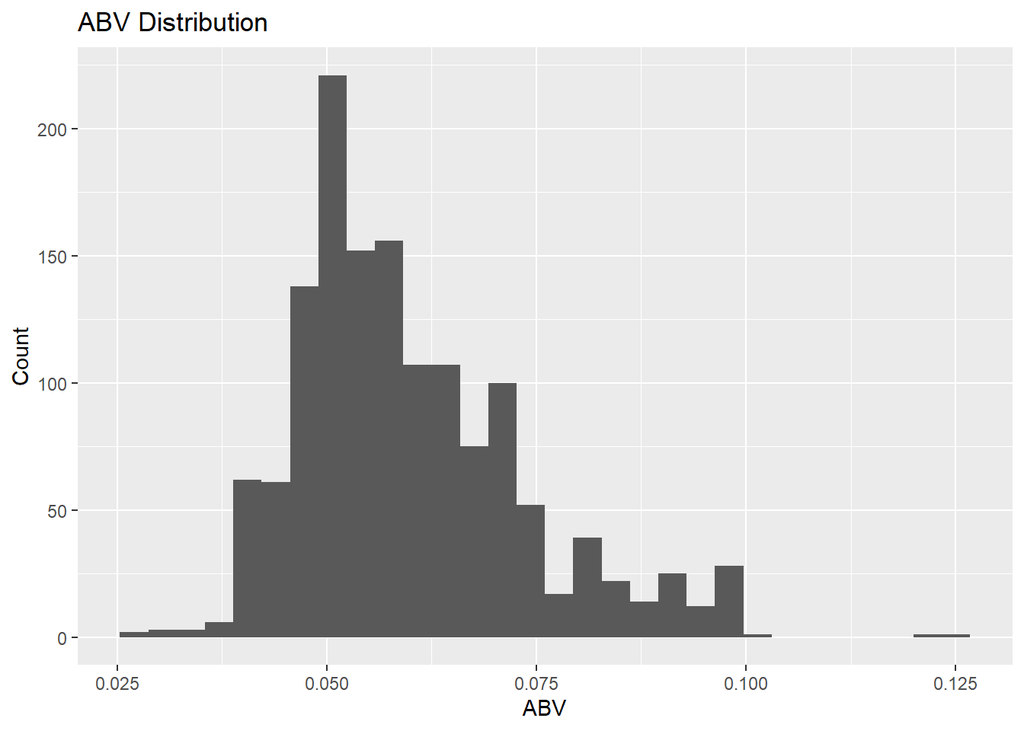

```r
#6) Comment on the summary statistics and distribution of the ABV variable.
#Most beers average around 0.052. Looking at the overall distribution, the data
#is right skewed. Our max for ABV is at 0.12500 and min is 0.02700.
ggplot(mergedB, aes(x = ABV)) + geom_histogram() + labs(title = "ABV Distribution", y = "Count")
```

Scatterplot

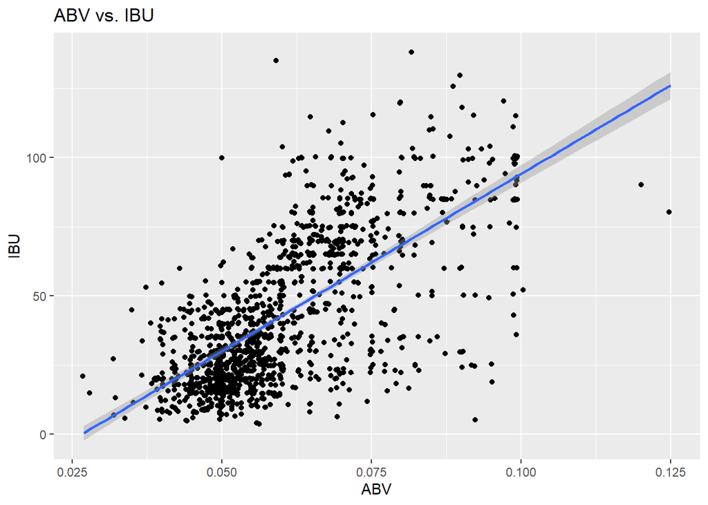

```r
#7) The relationship between the bitterness of the beer and its alcoholic content.
#Using a scatter plot we look into their relationship.
#The relationship between ABV and IBU appears to be linear and positive. There
#are many outliers (noise) from what can be seen.

ggplot(mergedB, aes(x = ABV, y = IBU)) + geom_point(size = 0.1) + geom_jitter() + stat_smooth(method = 'lm') + labs(title = "ABV vs. IBU")
```

For Loop

```r
#8) Investigating the difference between IPAs and Ale with respect to IBU and ABV.

#This guarantees the same values are produced.
set.seed(7)

#Using grepl to find rows that contain IPA and Ale within the Style column.
mergedBall= mergedB %>% filter(grepl("IPA|Ale", Style))

#Grabbing and then categorizing all Ales and IPAs through each row within the Sytle Column.
for (i in 1:length(mergedBall$Style))
  {
  if (grepl("IPA", mergedBall$Style[i]))
    {
    mergedBall$group[i]= "IPA"
  } else{
    mergedBall$group[i] = "Ale"
  }
}

mergedBall
```

```
##     Brewery_id                                           Name.x Beer_ID   ABV
## 1            1                                     Get Together    2692 0.045
## 2            1                                       Wall's End    2690 0.048
## 3            1                                          Pumpion    2689 0.060
## 4            2                                   Citra Ass Down    2686 0.080
## 5            2                                           A Beer    2683 0.042
## 6            2                                    Flesh Gourd'n    2681 0.066
## 7            2                                         Sho'nuff    2680 0.040
## 8            2                                      Rico Sauvin    2678 0.076
## 9            2                                 Coq de la Marche    2677 0.051
## 10           2                                     Pile of Face    2675 0.060
## 11           2                                   The Brown Note    2674 0.050
## 12           4                                   Habitus (2014)    2668 0.080
## 13           4                                            Solis    2667 0.075
## 14           4                                         Jucundus    2666 0.060
```

[output cut: 2820 more lines]

Train the model

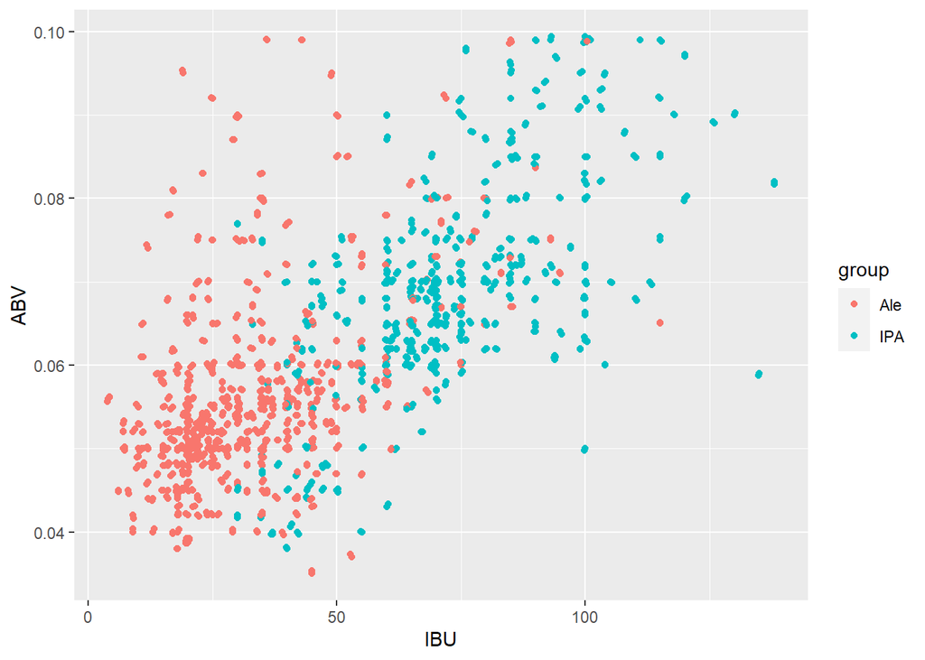

```r
#Creating the training and testing for IBU and ABV. Training the model.
trainIndices = sample(1:dim(mergedBall)[1], round(0.75* dim(mergedBall)[1]))
train = mergedBall[trainIndices,]
test = mergedBall[-trainIndices,]

#Seeing visually how Ales and IPAs interact with a scatter plot.
mergedBall %>% ggplot(aes(x = IBU, y = ABV, color = group)) + geom_point() + geom_jitter()
```